# mini project slides

## 범죄율에 영향을 미치는 요인 분석

기존에 있는 자료들은 단순히 범죄 수가 많은 지역들을 보는 자료들이 대부분이었습니다.  
단순히 인구가 많은 지역이어서 범죄 수가 많은 것은 아닐까 생각해보았습니다.  
인구밀도 대비 범죄율에 영향을 미치는 요인들을 분석해보았습니다.

### 사용한 자료들 / 공공데이터포털과 통계청 자료 활용

[figure not shown]

```python
import numpy as np
import pandas as pd
from pandas import DataFrame, Series
import matplotlib.pyplot as plt
import platform
from matplotlib import font_manager, rc
import seaborn as sns
%matplotlib inline
```

```python
from IPython.display import display, HTML

CSS = """
.output {
    flex-direction: row;
}
"""

HTML('<style>{}</style>'.format(CSS))
```

```python
df=pd.read_excel('범죄발생지.xlsx')
```

```python
df.head()
```

|  | 죄종별(1) | 죄종별(2) | 계 | 서울 | 부산 | 대구 | 인천 | 광주 | 대전 | 울산 | ... | 경남 거제 | 경남 김해 | 경남 밀양 | 경남 사천 | 경남 양산 | 경남 진주 | 경남 창원 | 경남 통영 | 제주 서귀포 | 제주 제주 |
| --- | --- | --- | --- | --- | --- | --- | --- | --- | --- | --- | --- | --- | --- | --- | --- | --- | --- | --- | --- | --- | --- |
| 0 | 계 | 소계 | 1849450 | 341925 | 133966 | 86094 | 103459 | 54287 | 49033 | 40330 | ... | 11726 | 19639 | 3353 | 4126 | 10083 | 11177 | 35928 | 7602 | 9820 | 27065 |
| 1 | 강력범죄 | 소계 | 25765 | 6683 | 1630 | 1028 | 1817 | 796 | 724 | 523 | ... | 114 | 188 | 31 | 42 | 128 | 127 | 357 | 50 | 128 | 365 |
| 2 | NaN | 살인기수 | 356 | 46 | 29 | 17 | 20 | 9 | 16 | 7 | ... | 2 | 5 | 2 | - | 3 | 2 | 3 | - | - | 4 |
| 3 | NaN | 살인미수등 | 558 | 100 | 43 | 12 | 28 | 8 | 9 | 15 | ... | - | 4 | - | 3 | 1 | 3 | 15 | 3 | 1 | 11 |
| 4 | NaN | 강도 | 1149 | 260 | 137 | 51 | 88 | 47 | 35 | 33 | ... | 5 | 10 | 4 | 1 | 7 | 6 | 26 | 1 | 1 | 24 |

5 rows × 88 columns

```python
df=df.fillna(value=None,method="ffill")
```

```python
df.replace({'-': 0}, inplace=True)
```

```python
df=df.fillna(0)
```

```python
df.head()
```

|  | 죄종별(1) | 죄종별(2) | 계 | 서울 | 부산 | 대구 | 인천 | 광주 | 대전 | 울산 | ... | 경남 거제 | 경남 김해 | 경남 밀양 | 경남 사천 | 경남 양산 | 경남 진주 | 경남 창원 | 경남 통영 | 제주 서귀포 | 제주 제주 |
| --- | --- | --- | --- | --- | --- | --- | --- | --- | --- | --- | --- | --- | --- | --- | --- | --- | --- | --- | --- | --- | --- |
| 0 | 계 | 소계 | 1849450 | 341925 | 133966 | 86094 | 103459 | 54287 | 49033 | 40330 | ... | 11726 | 19639 | 3353 | 4126 | 10083 | 11177 | 35928 | 7602 | 9820 | 27065 |
| 1 | 강력범죄 | 소계 | 25765 | 6683 | 1630 | 1028 | 1817 | 796 | 724 | 523 | ... | 114 | 188 | 31 | 42 | 128 | 127 | 357 | 50 | 128 | 365 |
| 2 | 강력범죄 | 살인기수 | 356 | 46 | 29 | 17 | 20 | 9 | 16 | 7 | ... | 2 | 5 | 2 | 0 | 3 | 2 | 3 | 0 | 0 | 4 |
| 3 | 강력범죄 | 살인미수등 | 558 | 100 | 43 | 12 | 28 | 8 | 9 | 15 | ... | 0 | 4 | 0 | 3 | 1 | 3 | 15 | 3 | 1 | 11 |
| 4 | 강력범죄 | 강도 | 1149 | 260 | 137 | 51 | 88 | 47 | 35 | 33 | ... | 5 | 10 | 4 | 1 | 7 | 6 | 26 | 1 | 1 | 24 |

5 rows × 88 columns

```python
df.columns
```

```
Index(['죄종별(1)', '죄종별(2)', '계', '서울', '부산', '대구', '인천', '광주', '대전', '울산', '세종',
       '경기 고양', '경기 과천', '경기 광명', '경기 광주', '경기 구리', '경기 군포', '경기 김포', '경기 남양주',
       '경기 동두천', '경기 부천', '경기 성남', '경기 수원', '경기 시흥', '경기 안산', '경기 안성', '경기 안양',
       '경기 양주', '경기 여주', '경기 오산', '경기 용인', '경기 의왕', '경기 의정부', '경기 이천', '경기 파주',
       '경기 평택', '경기 포천', '경기 하남', '경기 화성', '강원 강릉', '강원 동해', '강원 삼척', '강원 속초',
       '강원 원주', '강원 춘천', '강원 태백', '충북 제천', '충북 청주', '충북 충주', '충남 계룡', '충남 공주',
       '충남 논산', '충남 당진', '충남 보령', '충남 서산', '충남 아산', '충남 천안', '전북군산', '전북 김제',
       '전북 남원', '전북 익산', '전북 전주', '전북 정읍', '전남 광양', '전남 나주', '전남 목포', '전남 순천',
       '전남 여수', '경북 경산', '경북 경주', '경북 구미', '경북 김천', '경북 문경', '경북 상주', '경북 안동',
       '경북 영주', '경북 영천', '경북 포항', '경남 거제', '경남 김해', '경남 밀양', '경남 사천', '경남 양산',
       '경남 진주', '경남 창원', '경남 통영', '제주 서귀포', '제주 제주'],
      dtype='object')
```

```python
df=df.set_index(['죄종별(1)','죄종별(2)'])
```

```python
df.columns=df.columns.str.split(expand=True)
```

```python
df=df.sum(level=0,axis=1)
```

```python
df.columns
```

```
Index(['계', '서울', '부산', '대구', '인천', '광주', '대전', '울산', '세종', '경기', '강원', '충북',
       '충남', '전북군산', '전북', '전남', '경북', '경남', '제주'],
      dtype='object')
```

```python
df.columns=['계','서울','부산','대구','인천','광주','대전','울산','세종','경기','강원','충북','충남','전북 군산','전북','전남','경북','경남','제주']
```

```python
df.columns=df.columns.str.split(expand=True)
```

```python
df=df.sum(level=0,axis=1)
```

```python
dfa=df.loc[['교통범죄']]
```

```python
df1=df[:12]
```

```python
df=pd.concat([df1,dfa])
```

```python
df
```

| 죄종별(1) | 죄종별(2) | 계 | 서울 | 부산 | 대구 | 인천 | 광주 | 대전 | 울산 | 세종 | 경기 | 강원 | 충북 | 충남 | 전북 | 전남 | 경북 | 경남 | 제주 |
| --- | --- | --- | --- | --- | --- | --- | --- | --- | --- | --- | --- | --- | --- | --- | --- | --- | --- | --- | --- |
| 계 | 소계 | 1849450 | 341925 | 133966 | 86094 | 103459 | 54287 | 49033 | 40330 | 4661 | 466970 | 46234 | 42313 | 57257 | 47502 | 40655 | 73812 | 103634 | 36885 |
| 강력범죄 | 소계 | 25765 | 6683 | 1630 | 1028 | 1817 | 796 | 724 | 523 | 58 | 5753 | 518 | 547 | 810 | 596 | 464 | 756 | 1037 | 493 |
|  | 살인기수 | 356 | 46 | 29 | 17 | 20 | 9 | 16 | 7 | 1 | 84 | 7 | 4 | 11 | 8 | 7 | 16 | 17 | 4 |
|  | 살인미수등 | 558 | 100 | 43 | 12 | 28 | 8 | 9 | 15 | 1 | 157 | 11 | 15 | 23 | 18 | 8 | 18 | 29 | 12 |
|  | 강도 | 1149 | 260 | 137 | 51 | 88 | 47 | 35 | 33 | 3 | 185 | 22 | 19 | 39 | 38 | 20 | 40 | 60 | 25 |
|  | 강간 | 5155 | 1129 | 314 | 197 | 347 | 170 | 171 | 112 | 10 | 1144 | 150 | 128 | 173 | 129 | 108 | 204 | 208 | 84 |
|  | 유사강간 | 583 | 123 | 28 | 37 | 47 | 21 | 14 | 16 | 1 | 129 | 19 | 21 | 11 | 18 | 9 | 15 | 25 | 16 |
|  | 강제추행 | 16054 | 4667 | 951 | 632 | 1176 | 488 | 420 | 293 | 40 | 3644 | 264 | 314 | 468 | 332 | 267 | 398 | 600 | 318 |
|  | 기타 강간·강제추행등 | 408 | 72 | 30 | 14 | 27 | 15 | 15 | 9 | 0 | 85 | 6 | 7 | 14 | 16 | 9 | 7 | 24 | 8 |
|  | 방화 | 1502 | 286 | 98 | 68 | 84 | 38 | 44 | 38 | 2 | 325 | 39 | 39 | 71 | 37 | 36 | 58 | 74 | 26 |
| 절도범죄 | 소계 | 203037 | 46861 | 16777 | 9171 | 10025 | 6050 | 6981 | 4227 | 638 | 44120 | 4047 | 4959 | 7303 | 5276 | 3602 | 8093 | 11199 | 3500 |
| 폭력범죄 | 소계 | 309394 | 64601 | 20444 | 14557 | 19881 | 8610 | 9183 | 7803 | 822 | 74238 | 9048 | 7397 | 8601 | 8051 | 6632 | 11414 | 15808 | 6103 |
| 교통범죄 | 소계 | 600401 | 74270 | 32944 | 31682 | 30972 | 22137 | 14524 | 14105 | 1234 | 164462 | 18813 | 16314 | 18631 | 14310 | 17058 | 30116 | 37850 | 15702 |

```python
df.columns=['전국', '서울', '부산', '대구', '인천', '광주', '대전', '울산', '세종', '경기', '강원', '충북',
       '충남', '전북', '전남', '경북', '경남', '제주']
```

```python
df.loc['강력범죄','강간']=df.loc['강력범죄','강간']+df.loc['강력범죄','유사강간']+df.loc['강력범죄','강제추행']+df.loc['강력범죄','기타 강간·강제추행등']
```

```python
df.loc['강력범죄','살인기수']=df.loc['강력범죄','살인기수']+df.loc['강력범죄','살인미수등']
```

```python
df.drop(index=['살인미수등'],level=1,inplace=True)
```

```python
df.drop(index=['유사강간'],level=1,inplace=True)
df.drop(index=['강제추행'],level=1,inplace=True)
df.drop(index=['기타 강간·강제추행등'],level=1,inplace=True)
```

```python
df.T
```

| 죄종별(1) 죄종별(2) | 계 소계 | 강력범죄 소계 | 강력범죄 살인기수 | 강력범죄 강도 | 강력범죄 강간 | 강력범죄 방화 | 절도범죄 소계 | 폭력범죄 소계 | 교통범죄 소계 |
| --- | --- | --- | --- | --- | --- | --- | --- | --- | --- |
| 전국 | 1849450 | 25765 | 914 | 1149 | 22200 | 1502 | 203037 | 309394 | 600401 |
| 서울 | 341925 | 6683 | 146 | 260 | 5991 | 286 | 46861 | 64601 | 74270 |
| 부산 | 133966 | 1630 | 72 | 137 | 1323 | 98 | 16777 | 20444 | 32944 |
| 대구 | 86094 | 1028 | 29 | 51 | 880 | 68 | 9171 | 14557 | 31682 |
| 인천 | 103459 | 1817 | 48 | 88 | 1597 | 84 | 10025 | 19881 | 30972 |
| 광주 | 54287 | 796 | 17 | 47 | 694 | 38 | 6050 | 8610 | 22137 |
| 대전 | 49033 | 724 | 25 | 35 | 620 | 44 | 6981 | 9183 | 14524 |
| 울산 | 40330 | 523 | 22 | 33 | 430 | 38 | 4227 | 7803 | 14105 |
| 세종 | 4661 | 58 | 2 | 3 | 51 | 2 | 638 | 822 | 1234 |
| 경기 | 466970 | 5753 | 241 | 185 | 5002 | 325 | 44120 | 74238 | 164462 |
| 강원 | 46234 | 518 | 18 | 22 | 439 | 39 | 4047 | 9048 | 18813 |
| 충북 | 42313 | 547 | 19 | 19 | 470 | 39 | 4959 | 7397 | 16314 |
| 충남 | 57257 | 810 | 34 | 39 | 666 | 71 | 7303 | 8601 | 18631 |
| 전북 | 47502 | 596 | 26 | 38 | 495 | 37 | 5276 | 8051 | 14310 |
| 전남 | 40655 | 464 | 15 | 20 | 393 | 36 | 3602 | 6632 | 17058 |
| 경북 | 73812 | 756 | 34 | 40 | 624 | 58 | 8093 | 11414 | 30116 |
| 경남 | 103634 | 1037 | 46 | 60 | 857 | 74 | 11199 | 15808 | 37850 |
| 제주 | 36885 | 493 | 16 | 25 | 426 | 26 | 3500 | 6103 | 15702 |

```python
df2=pd.read_excel('인구__가구_및_주택__시군구_20180620155609.xlsx',index_col=0)
```

```python
df2.head()
```

| 행정구역별(시군구) | 총인구 | 남자 | 여자 | 내국인합계 | 내국인(남자) | 내국인(여자) | 외국인합계 | 외국인(남자) | 외국인(여자) | 주택합계 (호) | 단독주택 (호) | 아파트 (호) | 연립주택 (호) | 다세대주택 (호) | 비거주용 건물내 주택 (호) | 주택이외의 거처 (호) |
| --- | --- | --- | --- | --- | --- | --- | --- | --- | --- | --- | --- | --- | --- | --- | --- | --- |
| 전국 | 51269554 | 25696987 | 25572567 | 49855796 | 24881520 | 24974276 | 1413758 | 815467 | 598291 | 16692230 | 3967776 | 10029644 | 492469 | 2000783 | 201558 | 691672 |
| 서울특별시 | 9805506 | 4799115 | 5006391 | 9470339 | 4636374 | 4833965 | 335167 | 162741 | 172426 | 2830857 | 345269 | 1641383 | 116106 | 699446 | 28653 | 166859 |
| 부산광역시 | 3440484 | 1694026 | 1746458 | 3394316 | 1667106 | 1727210 | 46168 | 26920 | 19248 | 1174034 | 220798 | 750122 | 32073 | 157476 | 13565 | 57057 |
| 대구광역시 | 2461002 | 1223733 | 1237269 | 2430510 | 1205785 | 1224725 | 30492 | 17948 | 12544 | 761054 | 155568 | 532090 | 9433 | 53440 | 10523 | 16695 |
| 인천광역시 | 2913024 | 1465699 | 1447325 | 2841151 | 1423740 | 1417411 | 71873 | 41959 | 29914 | 958072 | 102632 | 588563 | 23268 | 235653 | 7956 | 50691 |

```python
df2.index=['전국','서울','부산','대구','인천','광주','대전','울산','세종','경기','강원','충북','충남','전북','전남','경북','경남','제주']
```

```python
df=df.T
```

```python
df['인구']=df2['총인구']
```

```python
df
```

| 죄종별(1) 죄종별(2) | 계 소계 | 강력범죄 소계 | 강력범죄 살인기수 | 강력범죄 강도 | 강력범죄 강간 | 강력범죄 방화 | 절도범죄 소계 | 폭력범죄 소계 | 교통범죄 소계 | 인구 |
| --- | --- | --- | --- | --- | --- | --- | --- | --- | --- | --- |
| 전국 | 1849450 | 25765 | 914 | 1149 | 22200 | 1502 | 203037 | 309394 | 600401 | 51269554 |
| 서울 | 341925 | 6683 | 146 | 260 | 5991 | 286 | 46861 | 64601 | 74270 | 9805506 |
| 부산 | 133966 | 1630 | 72 | 137 | 1323 | 98 | 16777 | 20444 | 32944 | 3440484 |
| 대구 | 86094 | 1028 | 29 | 51 | 880 | 68 | 9171 | 14557 | 31682 | 2461002 |
| 인천 | 103459 | 1817 | 48 | 88 | 1597 | 84 | 10025 | 19881 | 30972 | 2913024 |
| 광주 | 54287 | 796 | 17 | 47 | 694 | 38 | 6050 | 8610 | 22137 | 1501557 |
| 대전 | 49033 | 724 | 25 | 35 | 620 | 44 | 6981 | 9183 | 14524 | 1535445 |
| 울산 | 40330 | 523 | 22 | 33 | 430 | 38 | 4227 | 7803 | 14105 | 1166033 |
| 세종 | 4661 | 58 | 2 | 3 | 51 | 2 | 638 | 822 | 1234 | 242507 |
| 경기 | 466970 | 5753 | 241 | 185 | 5002 | 325 | 44120 | 74238 | 164462 | 12671956 |
| 강원 | 46234 | 518 | 18 | 22 | 439 | 39 | 4047 | 9048 | 18813 | 1521751 |
| 충북 | 42313 | 547 | 19 | 19 | 470 | 39 | 4959 | 7397 | 16314 | 1603404 |
| 충남 | 57257 | 810 | 34 | 39 | 666 | 71 | 7303 | 8601 | 18631 | 2132566 |
| 전북 | 47502 | 596 | 26 | 38 | 495 | 37 | 5276 | 8051 | 14310 | 1833168 |
| 전남 | 40655 | 464 | 15 | 20 | 393 | 36 | 3602 | 6632 | 17058 | 1796017 |
| 경북 | 73812 | 756 | 34 | 40 | 624 | 58 | 8093 | 11414 | 30116 | 2682169 |
| 경남 | 103634 | 1037 | 46 | 60 | 857 | 74 | 11199 | 15808 | 37850 | 3339633 |
| 제주 | 36885 | 493 | 16 | 25 | 426 | 26 | 3500 | 6103 | 15702 | 623332 |

```python
df3=pd.read_excel('거주지역별_주택소유_및_무주택_가구수_현황.xlsx',index_col=0)
```

```python
df3
```

| 거주지역별 | 총 가구(일반가구) | 주택소유 가구 | 무주택 가구 |
| --- | --- | --- | --- |
| 전국 | 19367696 | 10743492 | 8624204 |
| 서울특별시 | 3784705 | 1864059 | 1920646 |
| 부산광역시 | 1344170 | 783542 | 560628 |
| 대구광역시 | 935753 | 537709 | 398044 |
| 인천광역시 | 1062828 | 617040 | 445788 |
| 광주광역시 | 569372 | 324437 | 244935 |
| 대전광역시 | 590698 | 320525 | 270173 |
| 울산광역시 | 426027 | 266518 | 159509 |
| 세종특별자치시 | 90413 | 47215 | 43198 |
| 경기도 | 4484424 | 2466749 | 2017675 |
| 강원도 | 616346 | 338824 | 277522 |
| 충청북도 | 617914 | 351451 | 266463 |
| 충청남도 | 813730 | 456199 | 357531 |
| 전라북도 | 724678 | 415291 | 309387 |
| 전라남도 | 727197 | 421262 | 305935 |
| 경상북도 | 1076581 | 632790 | 443791 |
| 경상남도 | 1273523 | 773636 | 499887 |
| 제주특별자치도 | 229337 | 126245 | 103092 |

```python
df3.index=['전국', '서울', '부산', '대구', '인천', '광주', '대전', '울산', '세종', '경기', '강원', '충북',
       '충남', '전북', '전남', '경북', '경남', '제주']
```

```python
df3['주택 소유율']=df3['주택소유 가구']/df3['총 가구(일반가구)']
```

```python
df3.head()
```

|  | 총 가구(일반가구) | 주택소유 가구 | 무주택 가구 | 주택 소유율 |
| --- | --- | --- | --- | --- |
| 전국 | 19367696 | 10743492 | 8624204 | 0.554712 |
| 서울 | 3784705 | 1864059 | 1920646 | 0.492524 |
| 부산 | 1344170 | 783542 | 560628 | 0.582919 |
| 대구 | 935753 | 537709 | 398044 | 0.574627 |
| 인천 | 1062828 | 617040 | 445788 | 0.580564 |

```python
df['주택 소유율']=df3['주택 소유율']
```

```python
df
```

| 죄종별(1) 죄종별(2) | 계 소계 | 강력범죄 소계 | 강력범죄 살인기수 | 강력범죄 강도 | 강력범죄 강간 | 강력범죄 방화 | 절도범죄 소계 | 폭력범죄 소계 | 교통범죄 소계 | 인구 | 주택 소유율 |
| --- | --- | --- | --- | --- | --- | --- | --- | --- | --- | --- | --- |
| 전국 | 1849450 | 25765 | 914 | 1149 | 22200 | 1502 | 203037 | 309394 | 600401 | 51269554 | 0.554712 |
| 서울 | 341925 | 6683 | 146 | 260 | 5991 | 286 | 46861 | 64601 | 74270 | 9805506 | 0.492524 |
| 부산 | 133966 | 1630 | 72 | 137 | 1323 | 98 | 16777 | 20444 | 32944 | 3440484 | 0.582919 |
| 대구 | 86094 | 1028 | 29 | 51 | 880 | 68 | 9171 | 14557 | 31682 | 2461002 | 0.574627 |
| 인천 | 103459 | 1817 | 48 | 88 | 1597 | 84 | 10025 | 19881 | 30972 | 2913024 | 0.580564 |
| 광주 | 54287 | 796 | 17 | 47 | 694 | 38 | 6050 | 8610 | 22137 | 1501557 | 0.569816 |
| 대전 | 49033 | 724 | 25 | 35 | 620 | 44 | 6981 | 9183 | 14524 | 1535445 | 0.542621 |
| 울산 | 40330 | 523 | 22 | 33 | 430 | 38 | 4227 | 7803 | 14105 | 1166033 | 0.625589 |
| 세종 | 4661 | 58 | 2 | 3 | 51 | 2 | 638 | 822 | 1234 | 242507 | 0.522215 |
| 경기 | 466970 | 5753 | 241 | 185 | 5002 | 325 | 44120 | 74238 | 164462 | 12671956 | 0.550070 |
| 강원 | 46234 | 518 | 18 | 22 | 439 | 39 | 4047 | 9048 | 18813 | 1521751 | 0.549730 |
| 충북 | 42313 | 547 | 19 | 19 | 470 | 39 | 4959 | 7397 | 16314 | 1603404 | 0.568770 |
| 충남 | 57257 | 810 | 34 | 39 | 666 | 71 | 7303 | 8601 | 18631 | 2132566 | 0.560627 |
| 전북 | 47502 | 596 | 26 | 38 | 495 | 37 | 5276 | 8051 | 14310 | 1833168 | 0.573070 |
| 전남 | 40655 | 464 | 15 | 20 | 393 | 36 | 3602 | 6632 | 17058 | 1796017 | 0.579296 |
| 경북 | 73812 | 756 | 34 | 40 | 624 | 58 | 8093 | 11414 | 30116 | 2682169 | 0.587777 |
| 경남 | 103634 | 1037 | 46 | 60 | 857 | 74 | 11199 | 15808 | 37850 | 3339633 | 0.607477 |
| 제주 | 36885 | 493 | 16 | 25 | 426 | 26 | 3500 | 6103 | 15702 | 623332 | 0.550478 |

```python
df['인구대비범죄건수']=df['인구']/df['강력범죄','소계']
```

```python
df=df.drop(index='세종')
```

```python
df['인구대비 범죄 발생률']=df['계']['소계']/df['인구']
```

```python
df['인구대비 범죄 발생률']
```

[output not shown]

```python
df4=pd.read_excel('고위험음주율_시도_시_군_구.xlsx',index_col=0)
df5=pd.read_excel('시도별_소비자물가_변동률.xlsx',index_col=0)
df6=pd.read_excel('시도별_청년실업률.xlsx',index_col=0)
```

```python
df6=df6.drop(index='세종특별자치시')
```

```python
df6.index
```

```
Index(['전국', '서울특별시', '부산광역시', '대구광역시', '인천광역시', '광주광역시', '대전광역시', '울산광역시',
       '경기도', '강원도', '충청북도', '충청남도', '전라북도', '전라남도', '경상북도', '경상남도',
       '제주특별자치도'],
      dtype='object', name='행정구역별')
```

```python
df4.index=['전국', '서울', '부산', '대구', '인천', '광주', '대전', '울산', '경기', '강원', '충북',
       '충남', '전북', '전남', '경북', '경남', '제주']
df5.index=['전국', '서울', '부산', '대구', '인천', '광주', '대전', '울산', '경기', '강원', '충북',
       '충남', '전북', '전남', '경북', '경남', '제주']
df6.index=['전국', '서울', '부산', '대구', '인천', '광주', '대전', '울산', '경기', '강원', '충북',
       '충남', '전북', '전남', '경북', '경남', '제주']
```

```python
df5=df5.drop(columns=['2017. 12','2018. 01','2018. 02','2018. 03','2018. 04'])
```

```python
df6
```

|  | 2017 4/4 | 2018 1/4 |
| --- | --- | --- |
| 전국 | 9.0 | 10.0 |
| 서울 | 9.4 | 10.1 |
| 부산 | 10.1 | 9.3 |
| 대구 | 12.6 | 14.4 |
| 인천 | 8.6 | 9.5 |
| 광주 | 7.8 | 9.3 |
| 대전 | 8.5 | 11.5 |
| 울산 | 7.0 | 6.1 |
| 경기 | 8.8 | 9.3 |
| 강원 | 9.5 | 4.4 |
| 충북 | 5.1 | 6.8 |
| 충남 | 12.2 | 11.7 |
| 전북 | 5.0 | 11.5 |
| 전남 | 9.4 | 13.2 |
| 경북 | 9.0 | 16.6 |
| 경남 | 8.4 | 10.1 |
| 제주 | 5.7 | 5.3 |

```python
df4.columns=['고위험음주자']
df5.columns=['소비자물가변동률']
```

```python
df6=df6.drop(columns='2017 4/4')
```

```python
df6.columns=['청년실업률']
```

```python
display(df4.head())
display(df5.head())
display(df6.head())
```

|  | 고위험음주자 |
| --- | --- |
| 전국 | 154382 |
| 서울 | 17360 |
| 부산 | 10594 |
| 대구 | 5279 |
| 인천 | 6264 |

|  | 소비자물가변동률 |
| --- | --- |
| 전국 | 1.54 |
| 서울 | 1.59 |
| 부산 | 1.86 |
| 대구 | 1.80 |
| 인천 | 1.37 |

|  | 청년실업률 |
| --- | --- |
| 전국 | 10.0 |
| 서울 | 10.1 |
| 부산 | 9.3 |
| 대구 | 14.4 |
| 인천 | 9.5 |

```python
df['강력범죄','소계'][1:].corr(df5['소비자물가변동률'][1:])
```

```
0.06994642019017819
```

```python
display(df['강력범죄','소계'][1:]/2000)
display(df5['소비자물가변동률'][1:])
```

[output not shown]

```
서울    1.59
부산    1.86
대구    1.80
인천    1.37
광주    1.38
대전    1.69
울산    1.22
경기    1.48
강원    1.17
충북    1.79
충남    1.61
전북    1.35
전남    1.50
경북    1.36
경남    1.40
제주    1.78
Name: 소비자물가변동률, dtype: float64
```

```python
import matplotlib.pyplot as plt
```

```python
%matplotlib inline
```

```
Text(0,0.5,'지역별 소비자 물가 변동률')
```

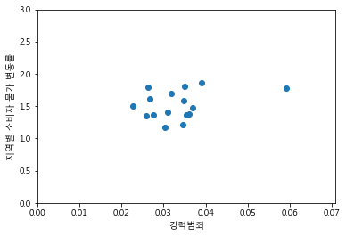

```python
plt.scatter(df['인구대비 범죄 발생률'][1:],df5['소비자물가변동률'][1:])
plt.xlim(0, )
plt.xlabel("강력범죄")
plt.ylim(0, 3)
plt.ylabel("지역별 소비자 물가 변동률")
```

```python
df['인구대비 범죄 발생률'][1:].corr(df5['소비자물가변동률'][1:])
```

```
0.3320355385095851
```

```python
df['절도범죄','소계'][1:].corr(df5['소비자물가변동률'][1:])
```

```
0.11118578545250893
```

```python
df['절도범죄','소계'][1:].corr(df6['청년실업률'][1:])
```

```
0.044184325432362524
```

```python
df4['고위험음주자'][1:].corr(df6['청년실업률'][1:])
```

```
0.12197371471760551
```

```python
df['강력범죄','소계'][1:].corr(df['주택 소유율'][1:])
```

```
-0.6099323992002719
```

```
Text(0,0.5,'주택소유율')
```

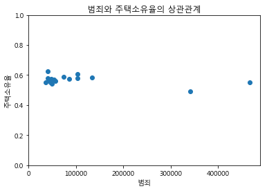

```python
plt.scatter(df['계','소계'][1:],df['주택 소유율'][1:])
plt.title('범죄와 주택소유율의 상관관계')
plt.xlim(0, )
plt.xlabel("범죄")
plt.ylim(0, 1)
plt.ylabel("주택소유율")
```

#### 주택소유율이 낮은 지역일수록 범죄가 많다.

```python
df['인구대비 범죄 발생률'][1:].corr(df4['고위험음주자'][1:])
```

```
-0.13465247981477035
```

```python
df['인구대비 범죄 발생률'][1:].corr(df['주택 소유율'][1:])
```

```
-0.17948217156351692
```

```python
df['인구대비 범죄 발생률'][1:].corr(df5['소비자물가변동률'][1:])
```

```
0.3320355385095851
```

```python
df['인구대비 범죄 발생률'][1:].corr(df6['청년실업률'][1:]/100)
```

```
-0.45596231227789347
```

```python
display(df['강력범죄','소계'][1:]/1000)
display(1-df['주택 소유율'][1:])
```

```
서울    6.683
부산    1.630
대구    1.028
인천    1.817
광주    0.796
대전    0.724
울산    0.523
경기    5.753
강원    0.518
충북    0.547
충남    0.810
전북    0.596
전남    0.464
경북    0.756
경남    1.037
제주    0.493
Name: (강력범죄, 소계), dtype: float64
```

```
서울    0.507476
부산    0.417081
대구    0.425373
인천    0.419436
광주    0.430184
대전    0.457379
울산    0.374411
경기    0.449930
강원    0.450270
충북    0.431230
충남    0.439373
전북    0.426930
전남    0.420704
경북    0.412223
경남    0.392523
제주    0.449522
Name: 주택 소유율, dtype: float64
```

```python
display(df['인구대비 범죄 발생률'][1:])
display(df6['청년실업률'][1:]/100)
```

```
서울    0.034871
부산    0.038938
대구    0.034983
인천    0.035516
광주    0.036154
대전    0.031934
울산    0.034587
경기    0.036851
강원    0.030382
충북    0.026389
충남    0.026849
전북    0.025913
전남    0.022636
경북    0.027520
경남    0.031032
제주    0.059174
Name: 인구대비 범죄 발생률, dtype: float64
```

```
서울    0.101
부산    0.093
대구    0.144
인천    0.095
광주    0.093
대전    0.115
울산    0.061
경기    0.093
강원    0.044
충북    0.068
충남    0.117
전북    0.115
전남    0.132
경북    0.166
경남    0.101
제주    0.053
Name: 청년실업률, dtype: float64
```

```python
display(df['인구대비 범죄 발생률'][1:])
display(df6['청년실업률'][1:]/100)
```

```
서울    0.034871
부산    0.038938
대구    0.034983
인천    0.035516
광주    0.036154
대전    0.031934
울산    0.034587
경기    0.036851
강원    0.030382
충북    0.026389
충남    0.026849
전북    0.025913
전남    0.022636
경북    0.027520
경남    0.031032
제주    0.059174
Name: 인구대비 범죄 발생률, dtype: float64
```

```
서울    0.101
부산    0.093
대구    0.144
인천    0.095
광주    0.093
대전    0.115
울산    0.061
경기    0.093
강원    0.044
충북    0.068
충남    0.117
전북    0.115
전남    0.132
경북    0.166
경남    0.101
제주    0.053
Name: 청년실업률, dtype: float64
```

```
Text(0,0.5,'지역별 청년 실업률')
```

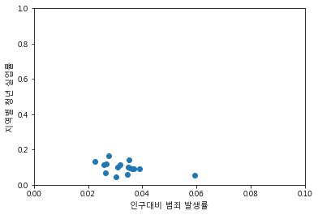

```python
plt.scatter(df['인구대비 범죄 발생률'][1:],df6['청년실업률'][1:]/100)
plt.xlim(0, 0.1)
plt.xlabel("인구대비 범죄 발생률")
plt.ylim(0, 1)
plt.ylabel("지역별 청년 실업률")
```

```python
df3
```

|  | 총 가구(일반가구) | 주택소유 가구 | 무주택 가구 | 주택 소유율 |
| --- | --- | --- | --- | --- |
| 전국 | 19367696 | 10743492 | 8624204 | 0.554712 |
| 서울 | 3784705 | 1864059 | 1920646 | 0.492524 |
| 부산 | 1344170 | 783542 | 560628 | 0.582919 |
| 대구 | 935753 | 537709 | 398044 | 0.574627 |
| 인천 | 1062828 | 617040 | 445788 | 0.580564 |
| 광주 | 569372 | 324437 | 244935 | 0.569816 |
| 대전 | 590698 | 320525 | 270173 | 0.542621 |
| 울산 | 426027 | 266518 | 159509 | 0.625589 |
| 세종 | 90413 | 47215 | 43198 | 0.522215 |
| 경기 | 4484424 | 2466749 | 2017675 | 0.550070 |
| 강원 | 616346 | 338824 | 277522 | 0.549730 |
| 충북 | 617914 | 351451 | 266463 | 0.568770 |
| 충남 | 813730 | 456199 | 357531 | 0.560627 |
| 전북 | 724678 | 415291 | 309387 | 0.573070 |
| 전남 | 727197 | 421262 | 305935 | 0.579296 |
| 경북 | 1076581 | 632790 | 443791 | 0.587777 |
| 경남 | 1273523 | 773636 | 499887 | 0.607477 |
| 제주 | 229337 | 126245 | 103092 | 0.550478 |

```python
df['총 가구']=df3['총 가구(일반가구)']
```

```python
df['주택소유 가구']=df3['주택소유 가구']
```

```python
df['무주택 가구']=df3['무주택 가구']
```

```python
df.head()
```

| 죄종별(1) 죄종별(2) | 계 소계 | 강력범죄 소계 | 강력범죄 살인기수 | 강력범죄 강도 | 강력범죄 강간 | 강력범죄 방화 | 절도범죄 소계 | 폭력범죄 소계 | 교통범죄 소계 | 인구 | 주택 소유율 | 인구대비 범죄 발생률 | 총 가구 | 주택소유 가구 | 무주택 가구 |
| --- | --- | --- | --- | --- | --- | --- | --- | --- | --- | --- | --- | --- | --- | --- | --- |
| 전국 | 1849450 | 25765 | 914 | 1149 | 22200 | 1502 | 203037 | 309394 | 600401 | 51269554 | 0.554712 | 0.036073 | 19367696 | 10743492 | 8624204 |
| 서울 | 341925 | 6683 | 146 | 260 | 5991 | 286 | 46861 | 64601 | 74270 | 9805506 | 0.492524 | 0.034871 | 3784705 | 1864059 | 1920646 |
| 부산 | 133966 | 1630 | 72 | 137 | 1323 | 98 | 16777 | 20444 | 32944 | 3440484 | 0.582919 | 0.038938 | 1344170 | 783542 | 560628 |
| 대구 | 86094 | 1028 | 29 | 51 | 880 | 68 | 9171 | 14557 | 31682 | 2461002 | 0.574627 | 0.034983 | 935753 | 537709 | 398044 |
| 인천 | 103459 | 1817 | 48 | 88 | 1597 | 84 | 10025 | 19881 | 30972 | 2913024 | 0.580564 | 0.035516 | 1062828 | 617040 | 445788 |

```python
foreigner=pd.read_excel('시도별_외국인주민_현황.xlsx',index_col=0)
```

```python
foreigner.index=['전국', '서울', '부산', '대구', '인천', '광주', '대전', '울산', '경기', '강원', '충북', '충남',
       '전북', '전남', '경북', '경남', '제주']
```

```python
foreigner.head()
```

|  | 주민등록인구 | 소계 | 한국국적을 가지지 않은 자 | 한국국적을 가지지 않은 외국인근로자 | 한국국적을 가지지 않은 결혼이민자 | 한국국적을 가지지 않은 유학생 | 외국인주민자녀 | 외국인부모의 외국인주민자녀 | 외국인-한국인부모의 외국인주민자녀 | 한국인 부모의 외국인주민자녀 |
| --- | --- | --- | --- | --- | --- | --- | --- | --- | --- | --- |
| 전국 | 51327916 | 1741919 | 1376162 | 608116 | 147382 | 84329 | 207693 | 14184 | 183732 | 9777 |
| 서울 | 10103233 | 457806 | 382094 | 116817 | 28707 | 32226 | 29790 | 4818 | 23957 | 1015 |
| 부산 | 3519401 | 57807 | 43734 | 17299 | 6789 | 6318 | 9142 | 202 | 8537 | 403 |
| 대구 | 2493264 | 37610 | 28181 | 12348 | 4767 | 3169 | 6369 | 241 | 5825 | 303 |
| 인천 | 2902608 | 91525 | 68610 | 30189 | 8816 | 2428 | 12334 | 1105 | 10639 | 590 |

```python
df['계','소계'].corr(foreigner['소계'])
```

```
0.9932551820897818
```

```python
df['강력범죄','소계'].corr(foreigner['소계'])
```

```
0.9938131394115665
```

```python
df['인구대비 범죄 발생률'].corr(foreigner['주민등록인구'])
```

```
0.0916701303522431
```

```python
df['인구대비 범죄 발생률'].corr(foreigner['소계'])
```

```
0.10037405827192268
```

```python
df['인구대비 범죄 발생률'].corr(foreigner['한국국적을 가지지 않은 자'])
```

```
0.10519914711662966
```

```python
df['인구대비 범죄 발생률'].corr(foreigner['한국국적을 가지지 않은 외국인근로자'])
```

```
0.09697651118864947
```

```python
df['인구대비 범죄 발생률'].corr(foreigner['한국국적을 가지지 않은 결혼이민자'])
```

```
0.08578706796288642
```

```python
df['인구대비 범죄 발생률'].corr(foreigner['한국국적을 가지지 않은 유학생'])
```

```
0.09096503691339108
```

```python
df['인구대비 범죄 발생률'].corr(foreigner['외국인주민자녀'])
```

```
0.06558108062403964
```

```python
df['인구대비 범죄 발생률'].corr(foreigner['외국인부모의 외국인주민자녀'])
```

```
0.12101592334415934
```

```python
foreigner['주민등록인구']
```

```
전국    51327916
서울    10103233
부산     3519401
대구     2493264
인천     2902608
광주     1475884
대전     1531809
울산     1166377
경기    12357830
강원     1544442
충북     1578933
충남     2062273
전북     1871560
전남     1905780
경북     2700794
경남     3350257
제주      607346
Name: 주민등록인구, dtype: int64
```

```python
from sklearn import preprocessing
```

```python
s2016=pd.read_csv('범죄발생장소_2016년.csv', engine='python')
```

```python
s2016=s2016[:7].replace('-','0')
```

```python
s2016=s2016.set_index(['범죄대분류','범죄중분류'])
```

```python
s2016=s2016.loc['강력범죄']
```

```python
s2016=s2016.T
```

```python
s2016=s2016.drop(index='기타')
```

```python
s2016.head()
```

| 범죄중분류 | 살인기수 | 살인미수등 | 강도 | 강간 | 유사강간 | 강제추행 | 기타 강간 강제추행등 |
| --- | --- | --- | --- | --- | --- | --- | --- |
| 계 | 356 | 558 | 1,149 | 5,155 | 583 | 16,054 | 408 |
| 아파트,연립다세대 | 83 | 79 | 74 | 1,027 | 101 | 887 | 86 |
| 단독주택 | 101 | 88 | 114 | 938 | 88 | 851 | 93 |
| 고속도로 | 0 | 1 | 2 | 3 | 0 | 12 | 0 |
| 노상 | 28 | 128 | 339 | 199 | 36 | 3,218 | 33 |

```python
def astype(x):
    return x.astype(float)
```

```python
def strreplace(x):
    return x.replace(',','')
```

```python
s2016['강도']=s2016['강도'].apply(strreplace)
s2016['강간']=s2016['강간'].apply(strreplace)
s2016['유사강간']=s2016['유사강간'].apply(strreplace)
s2016['강제추행']=s2016['강제추행'].apply(strreplace)
s2016['기타 강간 강제추행등']=s2016['기타 강간 강제추행등'].apply(strreplace)
s2016['살인기수']=s2016['살인기수'].apply(strreplace)
s2016['살인미수등']=s2016['살인미수등'].apply(strreplace)
```

```python
s2016['강도']=s2016['강도'].astype(int)
s2016['강간']=s2016['강간'].astype(int)
s2016['유사강간']=s2016['유사강간'].astype(int)
s2016['강제추행']=s2016['강제추행'].astype(int)
s2016['기타 강간 강제추행등']=s2016['기타 강간 강제추행등'].astype(int)
s2016['살인기수']=s2016['살인기수'].astype(int)
s2016['살인미수등']=s2016['살인미수등'].astype(int)
```

```python
s2016=s2016.T
```

```python
s2016.loc['살인기수']=s2016.loc['살인기수']+s2016.loc['살인미수등']
s2016.loc['강간']=s2016.loc['강간']+s2016.loc['유사강간']+s2016.loc['강제추행']+s2016.loc['기타 강간 강제추행등']
```

```python
s2016.drop(index=['살인미수등','유사강간','강제추행','기타 강간 강제추행등'],inplace=True)
```

```python
s2016=s2016.T
```

```python
s2016.columns=['살인','강도','강간']
```

```python
s2016
```

|  | 살인 | 강도 | 강간 |
| --- | --- | --- | --- |
| 계 | 914 | 1149 | 22200 |
| 아파트,연립다세대 | 162 | 74 | 2101 |
| 단독주택 | 189 | 114 | 1970 |
| 고속도로 | 1 | 2 | 15 |
| 노상 | 156 | 339 | 3486 |
| 백화점 | 0 | 1 | 10 |
| 슈퍼마켓 | 2 | 23 | 56 |
| 편의점 | 0 | 85 | 179 |
| 대형할인매장 | 0 | 1 | 8 |
| 상점 | 5 | 34 | 220 |
| 시장,노점 | 3 | 6 | 136 |
| 숙박업소,목욕탕 | 29 | 68 | 2071 |
| 유흥접객업소 | 49 | 75 | 2233 |
| 사무실 | 19 | 30 | 491 |
| 공장 | 5 | 3 | 53 |
| 공사장,광산 | 1 | 2 | 15 |
| 창고 | 2 | 1 | 13 |
| 역,대합실 | 2 | 1 | 294 |
| 지하철 | 0 | 0 | 787 |
| 기타표통수단내 | 13 | 22 | 1118 |
| 흥행장 | 0 | 0 | 57 |
| 유원지 | 9 | 7 | 251 |
| 학교 | 1 | 3 | 319 |
| 금융기관 | 1 | 3 | 13 |
| 의료기관 | 14 | 5 | 244 |
| 종교기관 | 4 | 1 | 54 |
| 산야 | 15 | 6 | 63 |
| 해상 | 6 | 0 | 1 |
| 부대 | 0 | 0 | 11 |
| 구금장소 | 0 | 0 | 7 |
| 공지 | 0 | 0 | 6 |
| 주차장 | 25 | 28 | 157 |
| 공중화장실 | 2 | 3 | 160 |
| 피씨방 | 0 | 10 | 52 |

```python
display(s2016[['살인']].sort_values(by='살인',ascending=False)[1:].head(10))
display(s2016[['강도']].sort_values(by='강도',ascending=False)[1:].head(10))
display(s2016[['강간']].sort_values(by='강간',ascending=False)[1:].head(10))
```

|  | 살인 |
| --- | --- |
| 단독주택 | 189 |
| 아파트,연립다세대 | 162 |
| 노상 | 156 |
| 유흥접객업소 | 49 |
| 숙박업소,목욕탕 | 29 |
| 주차장 | 25 |
| 사무실 | 19 |
| 산야 | 15 |
| 의료기관 | 14 |
| 기타표통수단내 | 13 |

|  | 강도 |
| --- | --- |
| 노상 | 339 |
| 단독주택 | 114 |
| 편의점 | 85 |
| 유흥접객업소 | 75 |
| 아파트,연립다세대 | 74 |
| 숙박업소,목욕탕 | 68 |
| 상점 | 34 |
| 사무실 | 30 |
| 주차장 | 28 |
| 슈퍼마켓 | 23 |

|  | 강간 |
| --- | --- |
| 노상 | 3486 |
| 유흥접객업소 | 2233 |
| 아파트,연립다세대 | 2101 |
| 숙박업소,목욕탕 | 2071 |
| 단독주택 | 1970 |
| 기타표통수단내 | 1118 |
| 지하철 | 787 |
| 사무실 | 491 |
| 학교 | 319 |
| 역,대합실 | 294 |

```python
s2015=pd.read_csv('2015년장소별범죄발생장소.csv', engine='python')
```

```python
s2015=s2015[:7].replace('-','0')
```

```python
s2015=s2015.set_index(['범죄대분류','범죄중분류'])
```

```python
s2015=s2015.loc['강력범죄']
```

```python
s2015=s2015.T
```

```python
s2015=s2015.drop(index='기타')
```

```python
s2015['강제추행'][12]=s2015['강제추행'][12].replace(',','')
```

```python
s2015['강제추행'][12]=int(s2015['강제추행'][12])
```

```python
s2015['강도']=s2015['강도'].astype(int)
s2015['강간']=s2015['강간'].astype(int)
s2015['유사강간']=s2015['유사강간'].astype(int)
s2015['강제추행']=s2015['강제추행'].astype(int)
s2015['기타 강간 강제추행등']=s2015['기타 강간 강제추행등'].astype(int)
s2015['살인기수']=s2015['살인기수'].astype(int)
s2015['살인미수등']=s2015['살인미수등'].astype(int)
```

```python
s2015=s2015.T
```

```python
s2015.loc['강간']=s2015.loc['강간']+s2015.loc['유사강간']+s2015.loc['강제추행']+s2015.loc['기타 강간 강제추행등']
```

```python
s2015.loc['살인기수']=s2015.loc['살인기수']+s2015.loc['살인미수등']
```

```python
s2015
```

| 범죄중분류 | 계 | 아파트,연립다세대 | 단독주택 | 고속도로 | 노상 | 백화점 | 슈퍼마켓 | 편의점 | 대형할인매장 | 상점 | ... | 의료기관 | 종교기관 | 산야 | 해상 | 부대 | 구금장소 | 공지 | 주차장 | 공중화장실 | 피씨방 |
| --- | --- | --- | --- | --- | --- | --- | --- | --- | --- | --- | --- | --- | --- | --- | --- | --- | --- | --- | --- | --- | --- |
| 살인기수 | 929 | 176 | 189 | 0 | 177 | 0 | 3 | 1 | 0 | 8 | ... | 14 | 4 | 5 | 5 | 0 | 0 | 0 | 17 | 2 | 0 |
| 살인미수등 | 564 | 92 | 88 | 0 | 134 | 0 | 2 | 0 | 0 | 7 | ... | 5 | 3 | 4 | 2 | 0 | 0 | 0 | 11 | 2 | 0 |
| 강도 | 1446 | 97 | 143 | 3 | 408 | 1 | 11 | 157 | 3 | 31 | ... | 2 | 4 | 12 | 0 | 0 | 0 | 0 | 32 | 4 | 5 |
| 강간 | 21286 | 1978 | 2080 | 20 | 3443 | 15 | 60 | 162 | 5 | 194 | ... | 233 | 75 | 70 | 1 | 7 | 7 | 3 | 176 | 150 | 46 |
| 유사강간 | 518 | 73 | 80 | 1 | 42 | 0 | 2 | 0 | 0 | 3 | ... | 5 | 1 | 6 | 0 | 0 | 0 | 0 | 7 | 18 | 0 |
| 강제추행 | 15059 | 900 | 842 | 18 | 3121 | 15 | 56 | 157 | 5 | 152 | ... | 208 | 46 | 36 | 1 | 7 | 7 | 1 | 106 | 72 | 39 |
| 기타 강간 강제추행등 | 558 | 97 | 164 | 0 | 37 | 0 | 1 | 0 | 0 | 4 | ... | 2 | 6 | 2 | 0 | 0 | 0 | 0 | 6 | 14 | 1 |

7 rows × 34 columns

```python
s2015.drop(index=['살인미수등','유사강간','강제추행','기타 강간 강제추행등'],inplace=True)
```

```python
s2015=s2015.T
```

```python
s2015.columns=['살인','강도','강간']
```

```python
display(s2015[['살인']].sort_values(by='살인',ascending=False)[1:].head(10))
display(s2015[['강도']].sort_values(by='강도',ascending=False)[1:].head(10))
display(s2015[['강간']].sort_values(by='강간',ascending=False)[1:].head(10))
```

|  | 살인 |
| --- | --- |
| 단독주택 | 189 |
| 노상 | 177 |
| 아파트,연립다세대 | 176 |
| 유흥접객업소 | 42 |
| 숙박업소,목욕탕 | 24 |
| 사무실 | 21 |
| 주차장 | 17 |
| 기타표통수단내 | 15 |
| 의료기관 | 14 |
| 유원지 | 9 |

|  | 강도 |
| --- | --- |
| 노상 | 408 |
| 편의점 | 157 |
| 단독주택 | 143 |
| 숙박업소,목욕탕 | 109 |
| 아파트,연립다세대 | 97 |
| 유흥접객업소 | 85 |
| 주차장 | 32 |
| 사무실 | 32 |
| 상점 | 31 |
| 기타표통수단내 | 23 |

|  | 강간 |
| --- | --- |
| 노상 | 3443 |
| 숙박업소,목욕탕 | 2173 |
| 단독주택 | 2080 |
| 아파트,연립다세대 | 1978 |
| 유흥접객업소 | 1946 |
| 기타표통수단내 | 938 |
| 지하철 | 788 |
| 사무실 | 475 |
| 학교 | 299 |
| 역,대합실 | 273 |

```python
s2014=pd.read_csv('2014년_범죄발생장소_장소별_.csv', engine='python',index_col=0)
```

```python
s2014=s2014[:7].replace('-','0')
```

```python
s2014=s2014.drop(columns='기타')
```

```python
s2014=s2014.T
```

```python
s2014['강간']=s2014['강간'].replace(',','')
```

```python
s2014['강간']=astype(s2014['강간'])
```

```python
s2014['유사강간']=astype(s2014['유사강간'])
s2014['강제추행']=astype(s2014['강제추행'])
s2014['기타강간·강제추행등']=astype(s2014['기타강간·강제추행등'])
```

```python
s2014.head()
```

| 범죄분류 | 살인기수 | 살인미수등 | 강도 | 강간 | 유사강간 | 강제추행 | 기타강간·강제추행등 |
| --- | --- | --- | --- | --- | --- | --- | --- |
| 계 | 372 | 541 | 1586 | 5078.0 | 375.0 | 14611.0 | 991.0 |
| 아파트·연립다세대 | 95 | 90 | 138 | 882.0 | 68.0 | 902.0 | 234.0 |
| 단독주택 | 95 | 102 | 182 | 954.0 | 63.0 | 790.0 | 280.0 |
| 고속도로 | 0 | 3 | 2 | 0.0 | 0.0 | 11.0 | 0.0 |
| 노상 | 59 | 126 | 423 | 249.0 | 30.0 | 3324.0 | 48.0 |

```python
def inttype(x):
    return int(x)
```

```python
s2014['살인기수']=s2014['살인기수'].apply(inttype)
s2014['살인미수등']=s2014['살인미수등'].apply(inttype)
```

```python
s2014.head()
```

| 범죄분류 | 살인기수 | 살인미수등 | 강도 | 강간 | 유사강간 | 강제추행 | 기타강간·강제추행등 |
| --- | --- | --- | --- | --- | --- | --- | --- |
| 계 | 372 | 541 | 1586 | 5078.0 | 375.0 | 14611.0 | 991.0 |
| 아파트·연립다세대 | 95 | 90 | 138 | 882.0 | 68.0 | 902.0 | 234.0 |
| 단독주택 | 95 | 102 | 182 | 954.0 | 63.0 | 790.0 | 280.0 |
| 고속도로 | 0 | 3 | 2 | 0.0 | 0.0 | 11.0 | 0.0 |
| 노상 | 59 | 126 | 423 | 249.0 | 30.0 | 3324.0 | 48.0 |

```python
s2014=s2014.T
```

```python
s2014.loc['살인기수']=s2014.loc['살인기수']+s2014.loc['살인미수등']
```

```python
s2014
```

| 범죄분류 | 계 | 아파트·연립다세대 | 단독주택 | 고속도로 | 노상 | 백화점 | 슈퍼마켓 | 편의점 | 대형할인매장 | 상점 | ... | 의료기관 | 종교기관 | 산야 | 해상 | 부대 | 구금장소 | 공지 | 주차장 | 공중화장실 | 피씨방 |
| --- | --- | --- | --- | --- | --- | --- | --- | --- | --- | --- | --- | --- | --- | --- | --- | --- | --- | --- | --- | --- | --- |
| 살인기수 | 913 | 185 | 197 | 3 | 185 | 0 | 1 | 2 | 0 | 5 | ... | 12 | 3 | 14 | 2 | 0 | 0 | 0 | 12 | 0 | 3 |
| 살인미수등 | 541 | 90 | 102 | 3 | 126 | 0 | 0 | 1 | 0 | 3 | ... | 6 | 2 | 6 | 1 | 0 | 0 | 0 | 5 | 0 | 2 |
| 강도 | 1586 | 138 | 182 | 2 | 423 | 0 | 26 | 154 | 1 | 36 | ... | 8 | 6 | 4 | 0 | 0 | 0 | 0 | 44 | 2 | 6 |
| 강간 | 5078 | 882 | 954 | 0 | 249 | 0 | 0 | 4 | 0 | 32 | ... | 24 | 21 | 34 | 0 | 2 | 0 | 3 | 52 | 42 | 3 |
| 유사강간 | 375 | 68 | 63 | 0 | 30 | 0 | 0 | 0 | 0 | 2 | ... | 2 | 1 | 1 | 0 | 0 | 0 | 0 | 12 | 11 | 1 |
| 강제추행 | 14611 | 902 | 790 | 11 | 3324 | 9 | 66 | 158 | 13 | 175 | ... | 179 | 39 | 26 | 1 | 5 | 3 | 2 | 110 | 66 | 43 |
| 기타강간·강제추행등 | 991 | 234 | 280 | 0 | 48 | 0 | 2 | 3 | 0 | 9 | ... | 1 | 2 | 4 | 0 | 0 | 0 | 0 | 8 | 16 | 1 |

7 rows × 34 columns

```python
s2014=s2014.T
```

```python
s2014=s2014.drop(columns='살인미수등')
```

```python
s2014.head()
```

| 범죄분류 | 살인기수 | 강도 | 강간 | 유사강간 | 강제추행 | 기타강간·강제추행등 |
| --- | --- | --- | --- | --- | --- | --- |
| 계 | 913 | 1586 | 5078 | 375 | 14611 | 991 |
| 아파트·연립다세대 | 185 | 138 | 882 | 68 | 902 | 234 |
| 단독주택 | 197 | 182 | 954 | 63 | 790 | 280 |
| 고속도로 | 3 | 2 | 0 | 0 | 11 | 0 |
| 노상 | 185 | 423 | 249 | 30 | 3324 | 48 |

```python
s2014['살인기수']=s2014['살인기수'].apply(inttype)
s2014['강도']=s2014['강도'].apply(inttype)
s2014['강간']=s2014['강간'].apply(inttype)
s2014['유사강간']=s2014['유사강간'].apply(inttype)
s2014['강제추행']=s2014['강제추행'].apply(inttype)
s2014['기타강간·강제추행등']=s2014['기타강간·강제추행등'].apply(inttype)
```

```python
s2014=s2014.T
```

```python
s2014.loc['강간']=s2014.loc['강간']+s2014.loc['유사강간']+s2014.loc['강제추행']+s2014.loc['기타강간·강제추행등']
```

```python
s2014
```

| 범죄분류 | 계 | 아파트·연립다세대 | 단독주택 | 고속도로 | 노상 | 백화점 | 슈퍼마켓 | 편의점 | 대형할인매장 | 상점 | ... | 의료기관 | 종교기관 | 산야 | 해상 | 부대 | 구금장소 | 공지 | 주차장 | 공중화장실 | 피씨방 |
| --- | --- | --- | --- | --- | --- | --- | --- | --- | --- | --- | --- | --- | --- | --- | --- | --- | --- | --- | --- | --- | --- |
| 살인기수 | 913 | 185 | 197 | 3 | 185 | 0 | 1 | 2 | 0 | 5 | ... | 12 | 3 | 14 | 2 | 0 | 0 | 0 | 12 | 0 | 3 |
| 강도 | 1586 | 138 | 182 | 2 | 423 | 0 | 26 | 154 | 1 | 36 | ... | 8 | 6 | 4 | 0 | 0 | 0 | 0 | 44 | 2 | 6 |
| 강간 | 21055 | 2086 | 2087 | 11 | 3651 | 9 | 68 | 165 | 13 | 218 | ... | 206 | 63 | 65 | 1 | 7 | 3 | 5 | 182 | 135 | 48 |
| 유사강간 | 375 | 68 | 63 | 0 | 30 | 0 | 0 | 0 | 0 | 2 | ... | 2 | 1 | 1 | 0 | 0 | 0 | 0 | 12 | 11 | 1 |
| 강제추행 | 14611 | 902 | 790 | 11 | 3324 | 9 | 66 | 158 | 13 | 175 | ... | 179 | 39 | 26 | 1 | 5 | 3 | 2 | 110 | 66 | 43 |
| 기타강간·강제추행등 | 991 | 234 | 280 | 0 | 48 | 0 | 2 | 3 | 0 | 9 | ... | 1 | 2 | 4 | 0 | 0 | 0 | 0 | 8 | 16 | 1 |

6 rows × 34 columns

```python
s2014.drop(index=['유사강간','강제추행','기타강간·강제추행등'],inplace=True)
```

```python
s2014=s2014.T
s2014.columns=['살인','강도','강간']
```

```python
display(s2014[['살인']].sort_values(by='살인',ascending=False)[1:].head(10))
display(s2014[['강도']].sort_values(by='강도',ascending=False)[1:].head(10))
display(s2014[['강간']].sort_values(by='강간',ascending=False)[1:].head(10))
```

|  | 살인 |
| --- | --- |
| 단독주택 | 197 |
| 노상 | 185 |
| 아파트·연립다세대 | 185 |
| 유흥접객업소 | 37 |
| 숙박업소·목욕탕 | 37 |
| 사무실 | 22 |
| 산야 | 14 |
| 주차장 | 12 |
| 의료기관 | 12 |
| 기타교통수단내 | 12 |

|  | 강도 |
| --- | --- |
| 노상 | 423 |
| 단독주택 | 182 |
| 편의점 | 154 |
| 아파트·연립다세대 | 138 |
| 유흥접객업소 | 101 |
| 숙박업소·목욕탕 | 89 |
| 주차장 | 44 |
| 상점 | 36 |
| 사무실 | 33 |
| 슈퍼마켓 | 26 |

|  | 강간 |
| --- | --- |
| 노상 | 3651 |
| 숙박업소·목욕탕 | 2302 |
| 단독주택 | 2087 |
| 아파트·연립다세대 | 2086 |
| 유흥접객업소 | 1984 |
| 기타교통수단내 | 1015 |
| 지하철 | 612 |
| 사무실 | 484 |
| 학교 | 264 |
| 유원지 | 231 |

## 3년간 살인 장소 추이 분석

```python
display(s2014[['살인']].sort_values(by='살인',ascending=False).head(10))
display(s2015[['살인']].sort_values(by='살인',ascending=False).head(10))
display(s2016[['살인']].sort_values(by='살인',ascending=False).head(10))
```

|  | 살인 |
| --- | --- |
| 계 | 913 |
| 단독주택 | 197 |
| 노상 | 185 |
| 아파트·연립다세대 | 185 |
| 유흥접객업소 | 37 |
| 숙박업소·목욕탕 | 37 |
| 사무실 | 22 |
| 산야 | 14 |
| 주차장 | 12 |
| 의료기관 | 12 |

|  | 살인 |
| --- | --- |
| 계 | 929 |
| 단독주택 | 189 |
| 노상 | 177 |
| 아파트,연립다세대 | 176 |
| 유흥접객업소 | 42 |
| 숙박업소,목욕탕 | 24 |
| 사무실 | 21 |
| 주차장 | 17 |
| 기타표통수단내 | 15 |
| 의료기관 | 14 |

|  | 살인 |
| --- | --- |
| 계 | 914 |
| 단독주택 | 189 |
| 아파트,연립다세대 | 162 |
| 노상 | 156 |
| 유흥접객업소 | 49 |
| 숙박업소,목욕탕 | 29 |
| 주차장 | 25 |
| 사무실 | 19 |
| 산야 | 15 |
| 의료기관 | 14 |

```python
k14=s2014[['살인']].sort_values(by='살인',ascending=False).head(10).T
k15=s2015[['살인']].sort_values(by='살인',ascending=False).head(10).T
k16=s2016[['살인']].sort_values(by='살인',ascending=False).head(10).T
```

```python
k14.columns=['계', '단독주택', '노상', '아파트,연립다세대', '유흥접객업소', '숙박업소,목욕탕', '사무실', '산야',
       '주차장', '의료기관']
```

```python
frames=[k14,k15,k16]
```

```python
c1416=pd.concat(frames).pct_change()
```

```python
c1416.drop(columns='기타표통수단내',inplace=True)
```

```python
c1416=(c1416+1).cumprod()
c1416.iloc[0]=1
```

```python
c1416
```

|  | 계 | 노상 | 단독주택 | 사무실 | 산야 | 숙박업소,목욕탕 | 아파트,연립다세대 | 유흥접객업소 | 의료기관 | 주차장 |
| --- | --- | --- | --- | --- | --- | --- | --- | --- | --- | --- |
| 살인 | 1.000000 | 1.000000 | 1.000000 | 1.000000 | 1.000000 | 1.000000 | 1.000000 | 1.000000 | 1.000000 | 1.000000 |
| 살인 | 1.017525 | 0.956757 | 0.959391 | 0.954545 | 1.000000 | 0.648649 | 0.951351 | 1.135135 | 1.166667 | 1.416667 |
| 살인 | 1.001095 | 0.843243 | 0.959391 | 0.863636 | 1.071429 | 0.783784 | 0.875676 | 1.324324 | 1.166667 | 2.083333 |

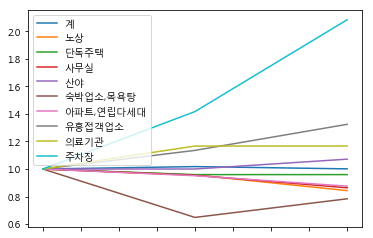

```python
c1416.plot()
```

### 3년간 살인사건 장소 추이로 볼 때 숙박업소에서 가장 많이 감소했고, 주차장에서 가장 많이 증가했다.

```python
display(s2014[['강간']].sort_values(by='강간',ascending=False).head(10))
display(s2015[['강간']].sort_values(by='강간',ascending=False).head(10))
display(s2016[['강간']].sort_values(by='강간',ascending=False).head(10))
```

|  | 강간 |
| --- | --- |
| 계 | 21055 |
| 노상 | 3651 |
| 숙박업소·목욕탕 | 2302 |
| 단독주택 | 2087 |
| 아파트·연립다세대 | 2086 |
| 유흥접객업소 | 1984 |
| 기타교통수단내 | 1015 |
| 지하철 | 612 |
| 사무실 | 484 |
| 학교 | 264 |

|  | 강간 |
| --- | --- |
| 계 | 21286 |
| 노상 | 3443 |
| 숙박업소,목욕탕 | 2173 |
| 단독주택 | 2080 |
| 아파트,연립다세대 | 1978 |
| 유흥접객업소 | 1946 |
| 기타표통수단내 | 938 |
| 지하철 | 788 |
| 사무실 | 475 |
| 학교 | 299 |

|  | 강간 |
| --- | --- |
| 계 | 22200 |
| 노상 | 3486 |
| 유흥접객업소 | 2233 |
| 아파트,연립다세대 | 2101 |
| 숙박업소,목욕탕 | 2071 |
| 단독주택 | 1970 |
| 기타표통수단내 | 1118 |
| 지하철 | 787 |
| 사무실 | 491 |
| 학교 | 319 |

```python
q14=s2014[['강간']].sort_values(by='강간',ascending=False).head(10).T
q15=s2015[['강간']].sort_values(by='강간',ascending=False).head(10).T
q16=s2016[['강간']].sort_values(by='강간',ascending=False).head(10).T
```

```python
q14.columns=['계', '노상', '숙박업소,목욕탕', '단독주택', '아파트,연립다세대', '유흥접객업소', '기타표통수단내', '지하철',
       '사무실', '학교']
```

```python
frames2=[q14,q15,q16]
```

```python
q1416=pd.concat(frames2).pct_change()
```

```python
q1416.columns=['계', '기타교통수단내', '노상', '단독주택', '사무실', '숙박업소,목욕탕', '아파트,연립다세대', '유흥접객업소',
       '지하철', '학교']
```

```python
q1416
```

|  | 계 | 기타교통수단내 | 노상 | 단독주택 | 사무실 | 숙박업소,목욕탕 | 아파트,연립다세대 | 유흥접객업소 | 지하철 | 학교 |
| --- | --- | --- | --- | --- | --- | --- | --- | --- | --- | --- |
| 강간 | NaN | NaN | NaN | NaN | NaN | NaN | NaN | NaN | NaN | NaN |
| 강간 | 0.010971 | -0.075862 | -0.056971 | -0.003354 | -0.018595 | -0.056038 | -0.051774 | -0.019153 | 0.287582 | 0.132576 |
| 강간 | 0.042939 | 0.191898 | 0.012489 | -0.052885 | 0.033684 | -0.046940 | 0.062184 | 0.147482 | -0.001269 | 0.066890 |

```python
q1416=(q1416+1).cumprod()
q1416.iloc[0]=1
```

```python
q1416
```

|  | 계 | 기타교통수단내 | 노상 | 단독주택 | 사무실 | 숙박업소,목욕탕 | 아파트,연립다세대 | 유흥접객업소 | 지하철 | 학교 |
| --- | --- | --- | --- | --- | --- | --- | --- | --- | --- | --- |
| 강간 | 1.000000 | 1.000000 | 1.000000 | 1.000000 | 1.000000 | 1.000000 | 1.000000 | 1.000000 | 1.000000 | 1.000000 |
| 강간 | 1.010971 | 0.924138 | 0.943029 | 0.996646 | 0.981405 | 0.943962 | 0.948226 | 0.980847 | 1.287582 | 1.132576 |
| 강간 | 1.054381 | 1.101478 | 0.954807 | 0.943939 | 1.014463 | 0.899652 | 1.007191 | 1.125504 | 1.285948 | 1.208333 |

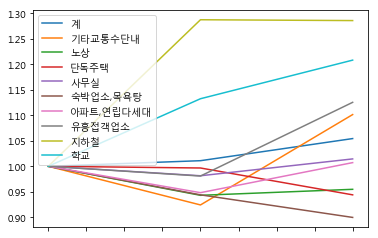

```python
q1416.plot()
```

### 3년간 강간사건 장소 추이로 볼 때 숙박업소에서 가장 많이 감소했고, 지하철과 학교에서 가장 많이 증가했다.

```python
s2011=pd.read_excel('범죄_발생장소_2011.xlsx',)
```

```python
pp1=pd.read_excel('시도별_1인가구_20180624172715.xlsx',index_col=0)
```

```python
pp1.head()
```

| 시도별 | 전체가구 (천가구) | 1인가구 (천가구) | 1인가구 비율 (%) |
| --- | --- | --- | --- |
| 전국 | 19018 | 5279 | 27.8 |
| 서울특별시 | 3675 | 1012 | 27.6 |
| 부산광역시 | 1316 | 367 | 27.9 |
| 대구광역시 | 924 | 241 | 26.1 |
| 인천광역시 | 1036 | 254 | 24.6 |

```python
df.head()
```

[output not shown]

```python
pp1.index=['전국', '서울', '부산', '대구', '인천', '광주', '대전', '울산', '경기', '강원', '충북', '충남',
       '전북', '전남', '경북', '경남', '제주']
```

```python
pp1.head()
```

|  | 전체가구 (천가구) | 1인가구 (천가구) | 1인가구 비율 (%) |
| --- | --- | --- | --- |
| 전국 | 19018 | 5279 | 27.8 |
| 서울 | 3675 | 1012 | 27.6 |
| 부산 | 1316 | 367 | 27.9 |
| 대구 | 924 | 241 | 26.1 |
| 인천 | 1036 | 254 | 24.6 |

```python
df['강력범죄','소계'][1:].corr(pp1['1인가구 (천가구)'][1:])
```

```
0.9595607289017573
```

```python
df['인구대비 범죄 발생률'][1:].corr(pp1['1인가구 비율 (%)'][1:])
```

```
-0.5313103984024344
```

```python
df.iloc[3,:].corr(df.iloc[4,:])
```

```
0.9999965566156783
```

```python
from scipy import stats
```

```python
df.head()
```

[output not shown]

```python
model=stats.linregress(df['인구대비 범죄 발생률'][1:],pp1['1인가구 비율 (%)'][1:])
```

```python
model.slope
```

```
-209.98313128578076
```

```python
model.intercept
```

```
35.9296203851827
```

```python
model.rvalue
```

```
-0.5313103984024345
```

```python
from scipy import polyval
```

```python
def linr(xdata,ydata):
    alpha = 0.000001
    xdata['intercept']=1.0
    n = xdata.shape[0]
    m = xdata.shape[1]
    print(xdata)
    err = np.zeros(n)
    w = np.ones((m, 1))

    for i in range(5000):
        print (w)
        h =np.dot(xdata, w)
        err = ydata.reshape((n,1))-h
        w = w - alpha*np.dot(xdata.T, err)
    return w
```

```python
display(df[['인구대비 범죄 발생률']][1:])
display(pp1['1인가구 비율 (%)'][1:])
```

| 죄종별(1) 죄종별(2) | 인구대비 범죄 발생률 |
| --- | --- |
| 서울 | 0.034871 |
| 부산 | 0.038938 |
| 대구 | 0.034983 |
| 인천 | 0.035516 |
| 광주 | 0.036154 |
| 대전 | 0.031934 |
| 울산 | 0.034587 |
| 경기 | 0.036851 |
| 강원 | 0.030382 |
| 충북 | 0.026389 |
| 충남 | 0.026849 |
| 전북 | 0.025913 |
| 전남 | 0.022636 |
| 경북 | 0.027520 |
| 경남 | 0.031032 |
| 제주 | 0.059174 |

```
서울    27.6
부산    27.9
대구    26.1
인천    24.6
광주    28.4
대전    29.9
울산    23.7
경기    23.8
강원    32.8
충북    31.8
충남    31.4
전북    31.3
전남    33.5
경북    33.5
경남    28.7
제주    27.8
Name: 1인가구 비율 (%), dtype: float64
```

```python
x=df['인구대비 범죄 발생률'][1:]
y=pp1['1인가구 비율 (%)'][1:]
```

```python
import scipy as sp
```

```python
pf1, res1, a, b, c=sp.polyfit(x,y,1,full=True)
```

```python
print('1차항 기울기와 절편 : %s'%pf1)
```

```
1차항 기울기와 절편 : [-209.98313129   35.92962039]
```

```python
print('1차항 잔차 : %s'%res1)
```

```
1차항 잔차 : [116.63493193]
```

```python
y2=df['주택 소유율'][1:]
```

```python
pf11, res11, a, b, c=sp.polyfit(x,y2,1,full=True)
```

인구대비 범죄 발생률과 주택 소유율간의 관계

```python
print('1차항 기울기와 절편 : %s'%pf11)
```

```
1차항 기울기와 절편 : [-0.63932447  0.58982383]
```

```python
print('1차항 잔차 : %s'%res11)
```

```
1차항 잔차 : [0.01277578]
```

1차항 회귀모델 생성(회귀방정식)

```python
p1=sp.poly1d(pf1)
print(p1)
```

```
-210 x + 35.93
```

2차항 회귀모델 생성(회귀방정식)

```python
pf2, res2, a, b, c=sp.polyfit(x,y,2,full=True)
```

```python
p2=sp.poly1d(pf2)
print(pf2)
```

```
[18171.24691152 -1683.62753904    63.68568147]
```

```python
colors=['g','r','b']
linesyles=['-','-.','--']
```

```python
df6.head()
```

|  | 청년실업률 |
| --- | --- |
| 전국 | 10.0 |
| 서울 | 10.1 |
| 부산 | 9.3 |
| 대구 | 14.4 |
| 인천 | 9.5 |

```python
model2 = linear_model.LinearRegression(fit_intercept=False)
y=df['인구대비 범죄 발생률'][1:]
x1=pp1['1인가구 비율 (%)'][1:]/100
x2=np.ones(16)
Xdata=DataFrame({'x1':x1,'x2':x2})
```

```python
result2=model2.fit(Xdata,y)
```

```python
Xdata
```

|  | x1 | x2 |
| --- | --- | --- |
| 서울 | 0.276 | 1.0 |
| 부산 | 0.279 | 1.0 |
| 대구 | 0.261 | 1.0 |
| 인천 | 0.246 | 1.0 |
| 광주 | 0.284 | 1.0 |
| 대전 | 0.299 | 1.0 |
| 울산 | 0.237 | 1.0 |
| 경기 | 0.238 | 1.0 |
| 강원 | 0.328 | 1.0 |
| 충북 | 0.318 | 1.0 |
| 충남 | 0.314 | 1.0 |
| 전북 | 0.313 | 1.0 |
| 전남 | 0.335 | 1.0 |
| 경북 | 0.335 | 1.0 |
| 경남 | 0.287 | 1.0 |
| 제주 | 0.278 | 1.0 |

```python
result2.coef_
```

```
array([-0.13443496,  0.07224333])
```

```python
opp=pp1['1인가구 비율 (%)'][1:]/100
```

```python
a=df['인구대비 범죄 발생률'][1:]-(opp*result2.coef_[0])-result2.coef_[1]
```

```python
a
```

```
서울   -0.000269
부산    0.004202
대구   -0.002172
인천   -0.003656
광주    0.002090
대전   -0.000113
울산   -0.005795
경기   -0.003397
강원    0.002233
충북   -0.003104
충남   -0.003182
전북   -0.004253
전남   -0.004571
경북    0.000312
경남   -0.002629
제주    0.024304
dtype: float64
```

잔차들의 합

```python
a.sum()<0.000000000000001
```

```
True
```

잔차들의 평균

```python
a.mean()
```

```
2.688821387764051e-17
```

```python
a.mean()<0.0000000000000001
```

```
True
```

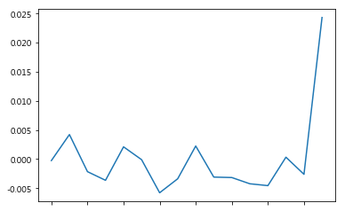

```python
a.plot()
```

```python
model2 = linear_model.LinearRegression(fit_intercept=False)
y=df['인구대비 범죄 발생률'][1:]
x1=df6['청년실업률'][1:]/100
x2=np.ones(16)
Xdata=DataFrame({'x1':x1,'x2':x2})
```

```python
result2=model2.fit(Xdata,y)
```

```python
result2.coef_
```

```
array([-0.11585961,  0.0448788 ])
```

```python
b=df['인구대비 범죄 발생률'][1:]-(df6['청년실업률'][1:]/100*result2.coef_[0])-result2.coef_[1]
```

```python
display(y)
display(x1)
```

```
서울    0.034871
부산    0.038938
대구    0.034983
인천    0.035516
광주    0.036154
대전    0.031934
울산    0.034587
경기    0.036851
강원    0.030382
충북    0.026389
충남    0.026849
전북    0.025913
전남    0.022636
경북    0.027520
경남    0.031032
제주    0.059174
Name: 인구대비 범죄 발생률, dtype: float64
```

[output not shown]

```python
b
```

```
서울    0.001694
부산    0.004834
대구    0.006788
인천    0.001644
광주    0.002050
대전    0.000379
울산   -0.003224
경기    0.002747
강원   -0.009399
충북   -0.010611
충남   -0.004474
전북   -0.005642
전남   -0.006949
경북    0.001873
경남   -0.002145
제주    0.020436
dtype: float64
```

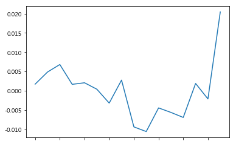

```python
b.plot()
```

```python
b.sum()
```

```
-1.5265566588595902e-16
```

```python
b.mean()
```

```
-9.540979117872439e-18
```

```python
a.mean()
```

```
2.688821387764051e-17
```

```python
a.mean()>b.mean()
```

```
True
```

### 잔차들의 합으로 볼 때 1인가구 비율(a)보다 청년실업률(b)에 관한 것이 더 신뢰성이 있다고 말할 수 있다.

```python
model3 = linear_model.LinearRegression(fit_intercept=False)
y=df['인구대비 범죄 발생률'][1:]
x1=df5['소비자물가변동률'][1:]/100
x2=np.ones(16)
Xdata=DataFrame({'x1':x1,'x2':x2})
```

```python
result3=model3.fit(Xdata,y)
```

```python
result3.coef_
```

```
array([1.27840454, 0.0139023 ])
```

```python
display(y)
display(x1)
display(x2)
```

```
서울    0.034871
부산    0.038938
대구    0.034983
인천    0.035516
광주    0.036154
대전    0.031934
울산    0.034587
경기    0.036851
강원    0.030382
충북    0.026389
충남    0.026849
전북    0.025913
전남    0.022636
경북    0.027520
경남    0.031032
제주    0.059174
Name: 인구대비 범죄 발생률, dtype: float64
```

```
서울    0.0159
부산    0.0186
대구    0.0180
인천    0.0137
광주    0.0138
대전    0.0169
울산    0.0122
경기    0.0148
강원    0.0117
충북    0.0179
충남    0.0161
전북    0.0135
전남    0.0150
경북    0.0136
경남    0.0140
제주    0.0178
Name: 소비자물가변동률, dtype: float64
```

```
array([1., 1., 1., 1., 1., 1., 1., 1., 1., 1., 1., 1., 1., 1., 1., 1.])
```

```python
q=y-(x1*result3.coef_[0])+result3.coef_[1]
```

```python
q
```

```
서울    0.028446
부산    0.029062
대구    0.025874
인천    0.031904
광주    0.032414
대전    0.024231
울산    0.032893
경기    0.031833
강원    0.029327
충북    0.017408
충남    0.020169
전북    0.022556
전남    0.017362
경북    0.024036
경남    0.027036
제주    0.050321
dtype: float64
```

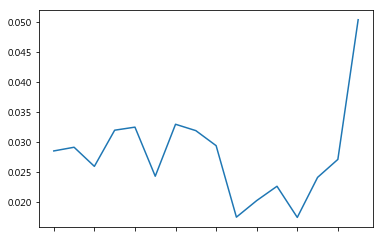

```python
q.plot()
```

```python
q.sum()
```

```
0.4448734599380553
```

```python
q.mean()
```

```
0.027804591246128454
```

```python
q.mean()<b.mean()
```

```
False
```

소비자물가 변동률(q)은 1인가구 비율(a)와 청년실업률(b)보다 상관관계가 낮으며, 회귀식으로 계산 시, 신뢰도가 떨어진다고 볼 수 있다.

```python
model = linear_model.LinearRegression()
y=df['인구대비 범죄 발생률'][1:]
x1=pp1['1인가구 비율 (%)'][1:]/100
x2=df6['청년실업률'][1:]/100
x3=np.ones(16)
Xdata=DataFrame({'x1':x1,'x2':x2,'x3':x3})
```

```python
display(y)
display(x1)
display(x2)
```

```
서울    0.034871
부산    0.038938
대구    0.034983
인천    0.035516
광주    0.036154
대전    0.031934
울산    0.034587
경기    0.036851
강원    0.030382
충북    0.026389
충남    0.026849
전북    0.025913
전남    0.022636
경북    0.027520
경남    0.031032
제주    0.059174
Name: 인구대비 범죄 발생률, dtype: float64
```

```
서울    0.276
부산    0.279
대구    0.261
인천    0.246
광주    0.284
대전    0.299
울산    0.237
경기    0.238
강원    0.328
충북    0.318
충남    0.314
전북    0.313
전남    0.335
경북    0.335
경남    0.287
제주    0.278
Name: 1인가구 비율 (%), dtype: float64
```

```
서울    0.101
부산    0.093
대구    0.144
인천    0.095
광주    0.093
대전    0.115
울산    0.061
경기    0.093
강원    0.044
충북    0.068
충남    0.117
전북    0.115
전남    0.132
경북    0.166
경남    0.101
제주    0.053
Name: 청년실업률, dtype: float64
```

```python
result=model.fit(Xdata,y)
```

```python
result.coef_
```

```
array([-0.11163222, -0.08601343,  0.        ])
```

```python
c=y-x1*result.coef_[0]+x2*result.coef_[1]
```

```python
c.sum()
```

```
0.9135147796706623
```

```python
c.mean()
```

```
0.05709467372941639
```

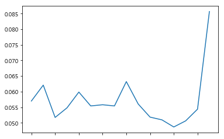

```python
c.plot()
```

```python
c=df['인구대비 범죄 발생률'][1:]-(opp*result2.coef_[0])-result2.coef_[1]
```

```python
from sklearn import linear_model

model4 = linear_model.LinearRegression()
y=df['인구대비 범죄 발생률'][1:]
x1=pp1['1인가구 비율 (%)'][1:]/100
x2=df['주택 소유율'][1:]
x3=df6['청년실업률'][1:]/100
x4=np.ones(16)
Xdata=DataFrame({'x1':x1,'x2':x2,'x3':x3,'x4':x4})
```

```python
result4=model4.fit(Xdata,y)
```

```python
result4.coef_
```

```
array([-0.11814346, -0.05712918, -0.080662  ,  0.        ])
```

```python
display(y)
display(x1)
display(x2)
display(x3)
```

```
서울    0.034871
부산    0.038938
대구    0.034983
인천    0.035516
광주    0.036154
대전    0.031934
울산    0.034587
경기    0.036851
강원    0.030382
충북    0.026389
충남    0.026849
전북    0.025913
전남    0.022636
경북    0.027520
경남    0.031032
제주    0.059174
Name: 인구대비 범죄 발생률, dtype: float64
```

```
서울    0.276
부산    0.279
대구    0.261
인천    0.246
광주    0.284
대전    0.299
울산    0.237
경기    0.238
강원    0.328
충북    0.318
충남    0.314
전북    0.313
전남    0.335
경북    0.335
경남    0.287
제주    0.278
Name: 1인가구 비율 (%), dtype: float64
```

```
서울    0.492524
부산    0.582919
대구    0.574627
인천    0.580564
광주    0.569816
대전    0.542621
울산    0.625589
경기    0.550070
강원    0.549730
충북    0.568770
충남    0.560627
전북    0.573070
전남    0.579296
경북    0.587777
경남    0.607477
제주    0.550478
Name: 주택 소유율, dtype: float64
```

```
서울    0.101
부산    0.093
대구    0.144
인천    0.095
광주    0.093
대전    0.115
울산    0.061
경기    0.093
강원    0.044
충북    0.068
충남    0.117
전북    0.115
전남    0.132
경북    0.166
경남    0.101
제주    0.053
Name: 청년실업률, dtype: float64
```

```python
qq=y-(x1*result4.coef_[0]-x2*result4.coef_[1]-x3*result4.coef_[2])
```

```python
qq.sum()
```

```
0.4325184036585363
```

```python
qq.mean()
```

```
0.027032400228658517
```

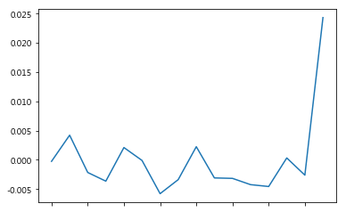

```python
a.plot()
```

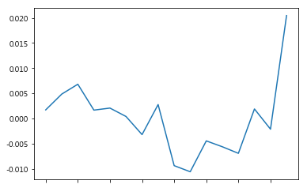

```python
b.plot()
```

[figure not shown]

```python
c.plot()
```

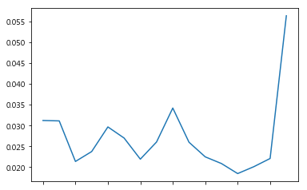

```python
qq.plot()
```